# Lab 3

## Wine dataset

We will be looking at a dataset that consists of wine statistics by wine category.

(1) Modify the following to see the head of the wine data file. (You should specify the relative path of the data.)

```python
!more wine.data.txt
```

```
#The next 14 lines are the variable names, then the remaining lines are the data in csv
Wine Class
Alcohol
Malic acid
Ash
Alcalinity of ash
Magnesium
Total phenols
Flavanoids
Nonflavanoid phenols
Proanthocyanins
Color intensity
Hue
OD280/OD315 of diluted wines
Proline
1,14.23,1.71,2.43,15.6,127,2.8,3.06,.28,2.29,5.64,1.04,3.92,1065
1,13.2,1.78,2.14,11.2,100,2.65,2.76,.26,1.28,4.38,1.05,3.4,1050
1,13.16,2.36,2.67,18.6,101,2.8,3.24,.3,2.81,5.68,1.03,3.17,1185
1,14.37,1.95,2.5,16.8,113,3.85,3.49,.24,2.18,7.8,.86,3.45,1480
1,13.24,2.59,2.87,21,118,2.8,2.69,.39,1.82,4.32,1.04,2.93,735
1,14.2,1.76,2.45,15.2,112,3.27,3.39,.34,1.97,6.75,1.05,2.85,1450
1,14.39,1.87,2.45,14.6,96,2.5,2.52,.3,1.98,5.25,1.02,3.58,1290
1,14.06,2.15,2.61,17.6,121,2.6,2.51,.31,1.25,5.05,1.06,3.58,1295
1,14.83,1.64,2.17,14,97,2.8,2.98,.29,1.98,5.2,1.08,2.85,1045
1,13.86,1.35,2.27,16,98,2.98,3.15,.22,1.85,7.22,1.01,3.55,1045
1,14.1,2.16,2.3,18,105,2.95,3.32,.22,2.38,5.75,1.25,3.17,1510
1,14.12,1.48,2.32,16.8,95,2.2,2.43,.26,1.57,5,1.17,2.82,1280
1,13.75,1.73,2.41,16,89,2.6,2.76,.29,1.81,5.6,1.15,2.9,1320
1,14.75,1.73,2.39,11.4,91,3.1,3.69,.43,2.81,5.4,1.25,2.73,1150
1,14.38,1.87,2.38,12,102,3.3,3.64,.29,2.96,7.5,1.2,3,1547
1,13.63,1.81,2.7,17.2,112,2.85,2.91,.3,1.46,7.3,1.28,2.88,1310
1,14.3,1.92,2.72,20,120,2.8,3.14,.33,1.97,6.2,1.07,2.65,1280
1,13.83,1.57,2.62,20,115,2.95,3.4,.4,1.72,6.6,1.13,2.57,1130
1,14.19,1.59,2.48,16.5,108,3.3,3.93,.32,1.86,8.7,1.23,2.82,1680
1,13.64,3.1,2.56,15.2,116,2.7,3.03,.17,1.66,5.1,.96,3.36,845
1,14.06,1.63,2.28,16,126,3,3.17,.24,2.1,5.65,1.09,3.71,780
1,12.93,3.8,2.65,18.6,102,2.41,2.41,.25,1.98,4.5,1.03,3.52,770
1,13.71,1.86,2.36,16.6,101,2.61,2.88,.27,1.69,3.8,1.11,4,1035
1,12.85,1.6,2.52,17.8,95,2.48,2.37,.26,1.46,3.93,1.09,3.63,1015
1,13.5,1.81,2.61,20,96,2.53,2.61,.28,1.66,3.52,1.12,3.82,845
```

[output cut: 138 more lines]

```
3,12.96,3.45,2.35,18.5,106,1.39,.7,.4,.94,5.28,.68,1.75,675
3,13.78,2.76,2.3,22,90,1.35,.68,.41,1.03,9.58,.7,1.68,615
3,13.73,4.36,2.26,22.5,88,1.28,.47,.52,1.15,6.62,.78,1.75,520
3,13.45,3.7,2.6,23,111,1.7,.92,.43,1.46,10.68,.85,1.56,695
3,12.82,3.37,2.3,19.5,88,1.48,.66,.4,.97,10.26,.72,1.75,685
3,13.58,2.58,2.69,24.5,105,1.55,.84,.39,1.54,8.66,.74,1.8,750
3,13.4,4.6,2.86,25,112,1.98,.96,.27,1.11,8.5,.67,1.92,630
3,12.2,3.03,2.32,19,96,1.25,.49,.4,.73,5.5,.66,1.83,510
3,12.77,2.39,2.28,19.5,86,1.39,.51,.48,.64,9.899999,.57,1.63,470
3,14.16,2.51,2.48,20,91,1.68,.7,.44,1.24,9.7,.62,1.71,660
3,13.71,5.65,2.45,20.5,95,1.68,.61,.52,1.06,7.7,.64,1.74,740
3,13.4,3.91,2.48,23,102,1.8,.75,.43,1.41,7.3,.7,1.56,750
3,13.27,4.28,2.26,20,120,1.59,.69,.43,1.35,10.2,.59,1.56,835
3,13.17,2.59,2.37,20,120,1.65,.68,.53,1.46,9.3,.6,1.62,840
3,14.13,4.1,2.74,24.5,96,2.05,.76,.56,1.35,9.2,.61,1.6,560
```

As you can see, the first several lines are the variable names and the remainder is comma separated lines of numbers.

(2) Create a file object with open(), and then read in the lines in sequence. Disregard the first line, read the next 14 in and save the variable names in a list, and save the rest in a list of lists of numbers (each line forms a list by splitting by commas).

```python
wine = open('../Lab 3/wine.data.txt')
wine.readline()
wlist = []
for line in wine:
    wlist.append(line.split('/n'))
wine.close()
```

```python
names = wlist[:14]
```

```python
names = [names[x][0].strip() for x in xrange(len(names))]
```

```python
names
```

```
['Wine Class',
 'Alcohol',
 'Malic acid',
 'Ash',
 'Alcalinity of ash',
 'Magnesium',
 'Total phenols',
 'Flavanoids',
 'Nonflavanoid phenols',
 'Proanthocyanins',
 'Color intensity',
 'Hue',
 'OD280/OD315 of diluted wines',
 'Proline']
```

```python
data = wlist[14:]
```

```python
data = [data[x][0].strip().split(',') for x in xrange(len(data))]
```

```python
data
```

[output not shown]

[output cut: 2437 more lines]

[output not shown]

(3) Import numpy and save the list of lists as an array object, where the entries are floats.

```python
import numpy as np
```

```python
data_array = np.asarray(data,dtype = np.float32)
```

```python
data_array.shape
```

```
(178L, 14L)
```

(4) Print the sample mean and standard deviations of each column (variable).

```python
print data_array.mean(0)
```

```
[  1.93820226e+00   1.30006142e+01   2.33634806e+00   2.36651850e+00
   1.94949455e+01   9.97415695e+01   2.29511213e+00   2.02926993e+00
   3.61853957e-01   1.59089923e+00   5.05808973e+00   9.57449555e-01
   2.61168432e+00   7.46893250e+02]
```

```python
print data_array.std(0)
```

```
[  7.72854209e-01   8.09543073e-01   1.11400366e+00   2.73572296e-01
   3.33016968e+00   1.42423096e+01   6.24090552e-01   9.96049106e-01
   1.24103241e-01   5.70748925e-01   2.31176472e+00   2.27928609e-01
   7.07993209e-01   3.14021667e+02]
```

(5) Normalize the data matrix by subtracting each column mean and divide by the column standard deviation for each column.

```python
mean = data_array.mean(0,keepdims=True)
```

```python
std = data_array.std(0,keepdims=True)
```

```python
norm = (data_array - mean)/std
```

```python
print norm
```

```
[[-1.21394467  1.51861644 -0.56224954 ...,  0.3621766   1.84792137
   1.01300895]
 [-1.21394467  0.24629405 -0.49941316 ...,  0.40604994  1.113451
   0.96524149]
 [-1.21394467  0.19688351  0.02123138 ...,  0.31830326  0.78858912
   1.39514816]
 ...,
 [ 1.37386549  0.33276337  1.7447449  ..., -1.61212575 -1.48544419
   0.28057539]
 [ 1.37386549  0.20923644  0.22769392 ..., -1.56825221 -1.40069747
   0.29649785]
 [ 1.37386549  1.39509058  1.58316517 ..., -1.52437878 -1.42894638
  -0.59516037]]
```

(6) Save the number of rows of the matrix as n.

```python
n,c = norm.shape
```

(7) The correlation matrix of a normalized matrix X can be computed as $$\frac{1}{n-1}X^\top X$$ Compute this.

```python
nmod = 1/float(n)-1
```

```python
corrmat = nmod*norm.T.dot(norm)
corrmat.shape
```

```
(14L, 14L)
```

(8) Use the following code to print an image that corresponds to the correlation matrix.

```
AxesImage(54,36;334.8x223.2)
```

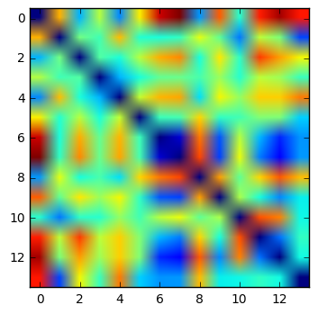

```
None
```

```python
from matplotlib import pyplot as plt
print plt.imshow(corrmat)
print plt.show(corrmat.all)
```

The following computes F-scores for individual ANOVAs for each variable by class. If you get finished early try to figure out what's going on.

```python
X = data_array
```

```python
N = np.array([(X[:,0] == i+1).sum() for i in range(3)])
V = np.array([X[X[:,0] == i+1,1:].var(axis=0) for i in range(3)])
M = np.array([X[X[:,0] == i+1,1:].mean(axis=0) for i in range(3)])
Bvar = (((M - X[:,1:].mean(axis=0))**2.).T * N).sum(axis=1) / 2
Wvar = (V.T * (N-1)).sum(axis=1) / (n - 3)
F = Bvar / Wvar
```

```python
print F
```

```
[ 137.38574649   37.58264285   13.52615768   36.35355179   12.62981874
   95.24379241  237.53611838   28.04714839   30.76268824  122.99582766
  102.92029556  192.99704153  211.40027272]
```